# Project Proposal

### 2번 가설

여기서는 와인의 quality가 각 요소들의 linear model로 표현된다는 가정 하에, ’와인의 type별로 와인의 quality에 영향을 주는 변수가 달라질 것이다.’라는 가설을 검정하였다. 먼저 index와 type을 제외한 나머지 변수가 모두 quality에 영향을 주는 linear model을 만들고, backward 변수선택법을 사용해 유의하지 않은 변수를 제거해주는 식으로 설명변수를 선택해 주었다. 이 과정을 red wine과 white wine에 대해서 수행한 후, 두 type간에 영향을 미치는 변수들이 다른지 여부를 살펴보았다.

```r
df_red_lm <- df_red[, c(2:13)]  # 회귀분석을 할 때 필요하지 않은 index와 type 열을 제외시킨 새로운 dataframe을 만들어 주었다.

lm_red_ori <- lm(quality~ ., data = df_red_lm)    # balance 값이 들어가지 않은 기본 linear model

lm_red_ori_step <- step(lm_red_ori, direction = "backward")
```

```
## Start:  AIC=-1166.02
## quality ~ fixed.acidity + volatile.acidity + citric.acid + residual.sugar +
##     chlorides + free.sulfur.dioxide + total.sulfur.dioxide +
##     density + pH + sulphates + alcohol
##
##                        Df Sum of Sq    RSS     AIC
## - density               1     0.045 549.83 -1167.9
## - residual.sugar        1     0.184 549.97 -1167.6
## - fixed.acidity         1     0.338 550.12 -1167.2
## <none>                              549.78 -1166.0
## - pH                    1     1.282 551.07 -1164.9
## - free.sulfur.dioxide   1     1.434 551.22 -1164.5
## - citric.acid           1     1.746 551.53 -1163.8
## - chlorides             1     5.631 555.41 -1154.4
## - total.sulfur.dioxide  1     8.857 558.64 -1146.6
## - sulphates             1    24.763 574.55 -1109.1
## - volatile.acidity      1    30.636 580.42 -1095.5
## - alcohol               1    38.429 588.21 -1077.6
##
## Step:  AIC=-1167.92
## quality ~ fixed.acidity + volatile.acidity + citric.acid + residual.sugar +
##     chlorides + free.sulfur.dioxide + total.sulfur.dioxide +
##     pH + sulphates + alcohol
##
##                        Df Sum of Sq    RSS      AIC
## - residual.sugar        1     0.143 549.97 -1169.57
## - fixed.acidity         1     0.442 550.27 -1168.84
## <none>                              549.83 -1167.92
## - free.sulfur.dioxide   1     1.506 551.33 -1166.26
## - citric.acid           1     1.753 551.58 -1165.66
## - pH                    1     2.261 552.09 -1164.43
## - chlorides             1     5.746 555.57 -1156.01
## - total.sulfur.dioxide  1     9.095 558.92 -1147.97
## - sulphates             1    25.905 575.73 -1108.32
## - volatile.acidity      1    31.400 581.23 -1095.61
## - alcohol               1    92.511 642.34  -961.84
##
## Step:  AIC=-1169.57
## quality ~ fixed.acidity + volatile.acidity + citric.acid + chlorides +
##     free.sulfur.dioxide + total.sulfur.dioxide + pH + sulphates +
```

[output cut: 13 more lines]

```
##
## Step:  AIC=-1170.4
## quality ~ volatile.acidity + citric.acid + chlorides + free.sulfur.dioxide +
##     total.sulfur.dioxide + pH + sulphates + alcohol
##
##                        Df Sum of Sq    RSS      AIC
## <none>                              550.45 -1170.40
## - citric.acid           1     1.207 551.66 -1169.47
## - free.sulfur.dioxide   1     1.813 552.27 -1168.00
## - pH                    1     4.747 555.20 -1160.91
## - chlorides             1     6.902 557.35 -1155.73
## - total.sulfur.dioxide  1    10.764 561.22 -1146.49
## - sulphates             1    26.309 576.76 -1109.93
## - volatile.acidity      1    31.234 581.69 -1098.55
## - alcohol               1    93.364 643.82  -962.77
```

```r
summary(lm_red_ori_step)
```

```
##
## Call:
## lm(formula = quality ~ volatile.acidity + citric.acid + chlorides +
##     free.sulfur.dioxide + total.sulfur.dioxide + pH + sulphates +
##     alcohol, data = df_red_lm)
##
## Residuals:
##      Min       1Q   Median       3Q      Max
## -2.26362 -0.37744 -0.04841  0.44512  2.05321
##
## Coefficients:
##                        Estimate Std. Error t value Pr(>|t|)
## (Intercept)           4.6206348  0.5064578   9.123  < 2e-16 ***
## volatile.acidity     -1.1024659  0.1269547  -8.684  < 2e-16 ***
## citric.acid          -0.2261431  0.1324980  -1.707 0.088099 .
## chlorides            -1.8119824  0.4438736  -4.082 4.73e-05 ***
## free.sulfur.dioxide   0.0048859  0.0023356   2.092 0.036635 *
## total.sulfur.dioxide -0.0039804  0.0007808  -5.098 3.93e-07 ***
## pH                   -0.4947301  0.1461288  -3.386 0.000731 ***
## sulphates             0.9294901  0.1166241   7.970 3.39e-15 ***
## alcohol               0.2826975  0.0188291  15.014  < 2e-16 ***
## ---
## Signif. codes:  0 '***' 0.001 '**' 0.01 '*' 0.05 '.' 0.1 ' ' 1
##
## Residual standard error: 0.6436 on 1329 degrees of freedom
## Multiple R-squared:  0.3608, Adjusted R-squared:  0.357
## F-statistic: 93.78 on 8 and 1329 DF,  p-value: < 2.2e-16
```

```r
df_white_lm <- df_white[, c(2:13)]  # 회귀분석을 할 때 필요하지 않은 index와 type 열을 제외시킨 새로운 dataframe을 만들어 주었다.

lm_white_ori <- lm(quality~ ., data = df_white_lm)    # balance 값이 들어가지 않은 기본 linear model

lm_white_ori_step <- step(lm_white_ori, direction = "backward")
```

```
## Start:  AIC=-2376.88
## quality ~ fixed.acidity + volatile.acidity + citric.acid + residual.sugar +
##     chlorides + free.sulfur.dioxide + total.sulfur.dioxide +
##     density + pH + sulphates + alcohol
##
##                        Df Sum of Sq    RSS     AIC
## - chlorides             1     0.016 2335.0 -2378.8
## - citric.acid           1     0.019 2335.0 -2378.8
## - total.sulfur.dioxide  1     0.048 2335.0 -2378.8
## <none>                              2335.0 -2376.9
## - fixed.acidity         1     5.154 2340.1 -2369.7
## - free.sulfur.dioxide   1     8.759 2343.7 -2363.3
## - pH                    1    20.092 2355.1 -2343.2
## - sulphates             1    22.110 2357.1 -2339.7
## - density               1    31.850 2366.8 -2322.5
## - alcohol               1    33.780 2368.8 -2319.2
## - residual.sugar        1    61.396 2396.4 -2270.9
## - volatile.acidity      1   134.494 2469.5 -2146.0
##
## Step:  AIC=-2378.85
## quality ~ fixed.acidity + volatile.acidity + citric.acid + residual.sugar +
##     free.sulfur.dioxide + total.sulfur.dioxide + density + pH +
##     sulphates + alcohol
##
##                        Df Sum of Sq    RSS     AIC
## - citric.acid           1     0.022 2335.0 -2380.8
## - total.sulfur.dioxide  1     0.049 2335.0 -2380.8
## <none>                              2335.0 -2378.8
## - fixed.acidity         1     5.395 2340.4 -2371.3
## - free.sulfur.dioxide   1     8.743 2343.7 -2365.3
## - pH                    1    20.816 2355.8 -2343.9
## - sulphates             1    22.157 2357.2 -2341.6
## - density               1    32.873 2367.9 -2322.7
## - alcohol               1    33.839 2368.8 -2321.0
## - residual.sugar        1    64.173 2399.2 -2268.1
## - volatile.acidity      1   135.990 2471.0 -2145.4
##
## Step:  AIC=-2380.81
## quality ~ fixed.acidity + volatile.acidity + residual.sugar +
##     free.sulfur.dioxide + total.sulfur.dioxide + density + pH +
```

[output cut: 13 more lines]

```
##
## Step:  AIC=-2382.72
## quality ~ fixed.acidity + volatile.acidity + residual.sugar +
##     free.sulfur.dioxide + density + pH + sulphates + alcohol
##
##                       Df Sum of Sq    RSS     AIC
## <none>                             2335.1 -2382.7
## - fixed.acidity        1     5.419 2340.5 -2375.1
## - free.sulfur.dioxide  1    12.205 2347.3 -2363.0
## - pH                   1    21.119 2356.2 -2347.3
## - sulphates            1    22.099 2357.2 -2345.6
## - alcohol              1    33.921 2369.0 -2324.7
## - density              1    35.022 2370.1 -2322.8
## - residual.sugar       1    66.041 2401.1 -2268.7
## - volatile.acidity     1   144.943 2480.0 -2134.3
```

```r
summary(lm_white_ori_step)
```

```
##
## Call:
## lm(formula = quality ~ fixed.acidity + volatile.acidity + residual.sugar +
##     free.sulfur.dioxide + density + pH + sulphates + alcohol,
##     data = df_white_lm)
##
## Residuals:
##     Min      1Q  Median      3Q     Max
## -3.8358 -0.4899 -0.0346  0.4647  3.1186
##
## Coefficients:
##                       Estimate Std. Error t value Pr(>|t|)
## (Intercept)          1.517e+02  1.899e+01   7.987 1.77e-15 ***
## fixed.acidity        6.747e-02  2.174e-02   3.103  0.00193 **
## volatile.acidity    -1.919e+00  1.196e-01 -16.050  < 2e-16 ***
## residual.sugar       8.379e-02  7.735e-03  10.834  < 2e-16 ***
## free.sulfur.dioxide  3.416e-03  7.334e-04   4.657 3.30e-06 ***
## density             -1.519e+02  1.925e+01  -7.889 3.85e-15 ***
## pH                   6.771e-01  1.105e-01   6.127 9.82e-10 ***
## sulphates            6.828e-01  1.090e-01   6.267 4.06e-10 ***
## alcohol              1.967e-01  2.533e-02   7.764 1.03e-14 ***
## ---
## Signif. codes:  0 '***' 0.001 '**' 0.01 '*' 0.05 '.' 0.1 ' ' 1
##
## Residual standard error: 0.7501 on 4150 degrees of freedom
## Multiple R-squared:  0.2801, Adjusted R-squared:  0.2787
## F-statistic: 201.8 on 8 and 4150 DF,  p-value: < 2.2e-16
```

분석 결과 red와 white 모두에서 유의하게 나온 변수는 volatile.acidity, free.sulfur.dioxide, pH, sulphates, alcohol이었고 red에만 유의하게 나온 변수는 citric.acid, chlorides, total.sulfur.dioxide, white에만 유의하게 나온 변수는 fixed.acidity, residual.sugar, density가 있다.

결과를 분석해 본다면, 우선 white에만 residual.sugar가 품질에 영향을 미친다는 것은 화이트 와인을 마시는 소비자가 상대적으로 당도를 더 중요하게 고려한다는 것으로 설명할 수 있을 것 같다. https://www.asiae.co.kr/article/2018060806513888770 에 의하면, 화이트와인은 레드와인과 달리 껍질이나 씨에서 색소나 탄닌을 수출하는 과정이 없다. 따라서 화이트와인에 대한 소비자의 요구 또한 신선하고, 너무 떫거나 쓰지 않는 것으로, 가볍고 산뜻한 와인을 좋아한다고 한다.

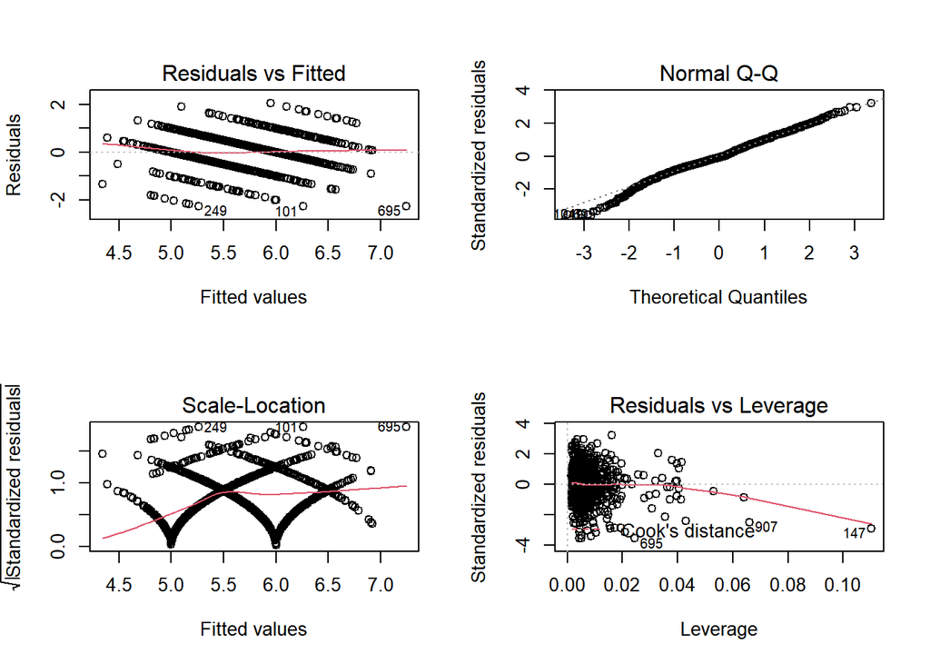

```r
par(mfrow = c(2, 2))

plot(lm_red_ori_step)
```

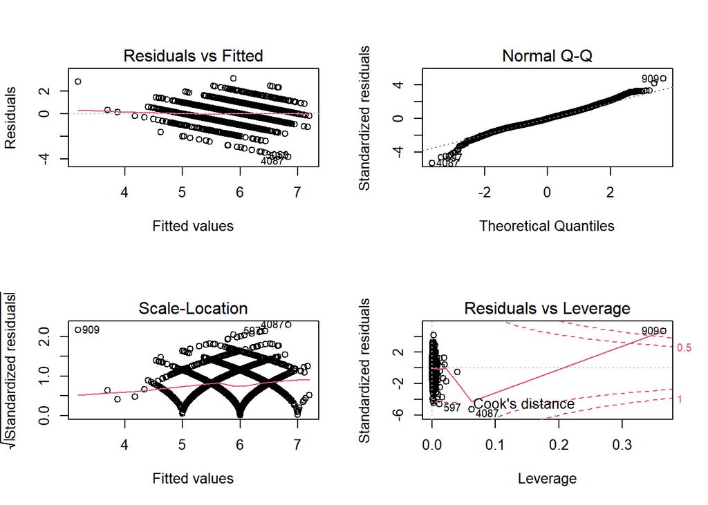

```r
plot(lm_white_ori_step)
```

```r
shapiro.test(lm_red_ori_step$residuals)
```

```
##
##  Shapiro-Wilk normality test
##
## data:  lm_red_ori_step$residuals
## W = 0.9919, p-value = 1.011e-06
```

```r
shapiro.test(lm_white_ori_step$residuals)
```

```
##
##  Shapiro-Wilk normality test
##
## data:  lm_white_ori_step$residuals
## W = 0.99017, p-value < 2.2e-16
```

### 3번 가설

```r
df_red_1 <- df_red_lm %>% mutate(balance = abs(residual.sugar - mean(residual.sugar)) + abs(citric.acid - mean(citric.acid)) + abs(alcohol - mean(alcohol)))  # (1)번 방법을 사용하여 balance를 구해 df_red_1 열에 추가해 줌
df_red_1 <- df_red_1 %>% mutate(residual.sugar = scale(residual.sugar, center = TRUE, scale = FALSE), citric.acid = scale(citric.acid, center = TRUE, scale = FALSE))

lm_red_1 <- lm(quality~ volatile.acidity + citric.acid + chlorides + free.sulfur.dioxide + total.sulfur.dioxide + pH + sulphates + alcohol + balance, data = df_red_1)  # balance까지 설명변수로 추가하여 구한 linear model
summary(lm_red_1)
```

```
##
## Call:
## lm(formula = quality ~ volatile.acidity + citric.acid + chlorides +
##     free.sulfur.dioxide + total.sulfur.dioxide + pH + sulphates +
##     alcohol + balance, data = df_red_1)
##
## Residuals:
##      Min       1Q   Median       3Q      Max
## -2.28156 -0.37760 -0.04865  0.44688  2.04573
##
## Coefficients:
##                        Estimate Std. Error t value Pr(>|t|)
## (Intercept)           4.5683768  0.4908769   9.307  < 2e-16 ***
## volatile.acidity     -1.1033232  0.1270162  -8.686  < 2e-16 ***
## citric.acid          -0.2285002  0.1326891  -1.722  0.08529 .
## chlorides            -1.8299283  0.4465759  -4.098 4.43e-05 ***
## free.sulfur.dioxide   0.0048039  0.0023465   2.047  0.04083 *
## total.sulfur.dioxide -0.0039969  0.0007823  -5.109 3.71e-07 ***
## pH                   -0.4944185  0.1461784  -3.382  0.00074 ***
## sulphates             0.9322425  0.1168914   7.975 3.26e-15 ***
## alcohol               0.2810964  0.0193107  14.556  < 2e-16 ***
## balance               0.0050746  0.0134988   0.376  0.70703
## ---
## Signif. codes:  0 '***' 0.001 '**' 0.01 '*' 0.05 '.' 0.1 ' ' 1
##
## Residual standard error: 0.6438 on 1328 degrees of freedom
## Multiple R-squared:  0.3609, Adjusted R-squared:  0.3566
## F-statistic: 83.32 on 9 and 1328 DF,  p-value: < 2.2e-16
```

```r
df_red_2 <- df_red_lm %>% mutate(balance = sqrt((residual.sugar - mean(residual.sugar))^2 + (citric.acid - mean(citric.acid))^2) + (alcohol - mean(alcohol))^2)  # (2)번 방법을 사용하여 balance를 구해 df_red_1 열에 추가해 줌
df_red_2 <- df_red_2 %>% mutate(residual.sugar = scale(residual.sugar, center = TRUE, scale = FALSE), citric.acid = scale(citric.acid, center = TRUE, scale = FALSE))  # balance까지 설명변수로 추가하여 구한 linear model
lm_red_2 <- lm(quality~ volatile.acidity + citric.acid + chlorides + free.sulfur.dioxide + total.sulfur.dioxide + pH + sulphates + alcohol + balance, data = df_red_2)
summary(lm_red_2)
```

```
##
## Call:
## lm(formula = quality ~ volatile.acidity + citric.acid + chlorides +
##     free.sulfur.dioxide + total.sulfur.dioxide + pH + sulphates +
##     alcohol + balance, data = df_red_2)
##
## Residuals:
##      Min       1Q   Median       3Q      Max
## -2.26019 -0.37320 -0.04704  0.44362  2.06461
##
## Coefficients:
##                       Estimate Std. Error t value Pr(>|t|)
## (Intercept)           4.524083   0.497622   9.091  < 2e-16 ***
## volatile.acidity     -1.103624   0.127025  -8.688  < 2e-16 ***
## citric.acid          -0.226055   0.132539  -1.706  0.08832 .
## chlorides            -1.789623   0.447235  -4.002 6.64e-05 ***
## free.sulfur.dioxide   0.004897   0.002337   2.096  0.03628 *
## total.sulfur.dioxide -0.003934   0.000789  -4.985 7.00e-07 ***
## pH                   -0.494918   0.146175  -3.386  0.00073 ***
## sulphates             0.926356   0.116902   7.924 4.82e-15 ***
## alcohol               0.286749   0.021192  13.531  < 2e-16 ***
## balance              -0.004037   0.009677  -0.417  0.67661
## ---
## Signif. codes:  0 '***' 0.001 '**' 0.01 '*' 0.05 '.' 0.1 ' ' 1
##
## Residual standard error: 0.6438 on 1328 degrees of freedom
## Multiple R-squared:  0.3609, Adjusted R-squared:  0.3566
## F-statistic: 83.33 on 9 and 1328 DF,  p-value: < 2.2e-16
```

```r
df_white_1 <- df_white_lm %>% mutate(balance = abs(residual.sugar - mean(residual.sugar)) + abs(citric.acid - mean(citric.acid)) + abs(alcohol - mean(alcohol)))  # (1)번 방법을 사용하여 balance를 구해 df_red_1 열에 추가해 줌
df_white_1 <- df_white_1 %>% mutate(residual.sugar = scale(residual.sugar, center = TRUE, scale = FALSE), citric.acid = scale(citric.acid, center = TRUE, scale = FALSE))

lm_white_1 <- lm(quality~ fixed.acidity + volatile.acidity + residual.sugar + free.sulfur.dioxide + density + pH + sulphates + alcohol + balance, data = df_white_1)  # balance까지 설명변수로 추가하여 구한 linear model
summary(lm_white_1)
```

```
##
## Call:
## lm(formula = quality ~ fixed.acidity + volatile.acidity + residual.sugar +
##     free.sulfur.dioxide + density + pH + sulphates + alcohol +
##     balance, data = df_white_1)
##
## Residuals:
##     Min      1Q  Median      3Q     Max
## -3.8307 -0.4899 -0.0352  0.4681  3.1151
##
## Coefficients:
##                       Estimate Std. Error t value Pr(>|t|)
## (Intercept)          1.515e+02  1.915e+01   7.910 3.28e-15 ***
## fixed.acidity        6.682e-02  2.181e-02   3.064  0.00219 **
## volatile.acidity    -1.922e+00  1.197e-01 -16.048  < 2e-16 ***
## residual.sugar       8.405e-02  7.763e-03  10.827  < 2e-16 ***
## free.sulfur.dioxide  3.391e-03  7.360e-04   4.608 4.19e-06 ***
## density             -1.511e+02  1.936e+01  -7.802 7.67e-15 ***
## pH                   6.731e-01  1.110e-01   6.064 1.44e-09 ***
## sulphates            6.832e-01  1.090e-01   6.270 3.99e-10 ***
## alcohol              1.978e-01  2.551e-02   7.755 1.10e-14 ***
## balance             -1.782e-03  4.548e-03  -0.392  0.69527
## ---
## Signif. codes:  0 '***' 0.001 '**' 0.01 '*' 0.05 '.' 0.1 ' ' 1
##
## Residual standard error: 0.7502 on 4149 degrees of freedom
## Multiple R-squared:  0.2801, Adjusted R-squared:  0.2785
## F-statistic: 179.4 on 9 and 4149 DF,  p-value: < 2.2e-16
```

```r
df_white_2 <- df_white_lm %>% mutate(balance = sqrt((residual.sugar - mean(residual.sugar))^2 + (citric.acid - mean(citric.acid))^2) + (alcohol - mean(alcohol))^2)  # (2)번 방법을 사용하여 balance를 구해 df_red_1 열에 추가해 줌
df_white_2 <- df_white_2 %>% mutate(residual.sugar = scale(residual.sugar, center = TRUE, scale = FALSE), citric.acid = scale(citric.acid, center = TRUE, scale = FALSE))  # balance까지 설명변수로 추가하여 구한 linear model
lm_white_2 <- lm(quality~ fixed.acidity + volatile.acidity + residual.sugar + free.sulfur.dioxide + density + pH + sulphates + alcohol + balance, data = df_white_2)
summary(lm_white_2)
```

```
##
## Call:
## lm(formula = quality ~ fixed.acidity + volatile.acidity + residual.sugar +
##     free.sulfur.dioxide + density + pH + sulphates + alcohol +
##     balance, data = df_white_2)
##
## Residuals:
##     Min      1Q  Median      3Q     Max
## -3.8446 -0.4916 -0.0328  0.4623  3.1295
##
## Coefficients:
##                       Estimate Std. Error t value Pr(>|t|)
## (Intercept)          1.543e+02  1.912e+01   8.069 9.16e-16 ***
## fixed.acidity        6.987e-02  2.184e-02   3.200  0.00139 **
## volatile.acidity    -1.920e+00  1.196e-01 -16.059  < 2e-16 ***
## residual.sugar       8.290e-02  7.772e-03  10.667  < 2e-16 ***
## free.sulfur.dioxide  3.466e-03  7.346e-04   4.718 2.46e-06 ***
## density             -1.540e+02  1.933e+01  -7.964 2.14e-15 ***
## pH                   6.910e-01  1.112e-01   6.216 5.59e-10 ***
## sulphates            6.817e-01  1.090e-01   6.257 4.33e-10 ***
## alcohol              1.911e-01  2.576e-02   7.419 1.42e-13 ***
## balance              4.611e-03  3.953e-03   1.167  0.24343
## ---
## Signif. codes:  0 '***' 0.001 '**' 0.01 '*' 0.05 '.' 0.1 ' ' 1
##
## Residual standard error: 0.7501 on 4149 degrees of freedom
## Multiple R-squared:  0.2803, Adjusted R-squared:  0.2787
## F-statistic: 179.6 on 9 and 4149 DF,  p-value: < 2.2e-16
```

네 가지 경우 모두 balance 값이 유의하지 않다고 나왔다. 사실 예상과는 매우 다른 결과가 나왔는데, balance를 sugar_balance, acid_balance, alcohol_balance 등으로 나누어서 검정해 보아도 모두 유의하지 않은 결과가 나타났다. 정확한 원인은 알 수 없으나 나름대로 추청한다면 다음과 같은 이유가 있을 수 있겠다.

또한 이 가설과 별개로, ‘과연 linear model이 와인의 quality를 평가하는 데(accuracy라는 기준을 가지고) 적절한 모형인가?’ 라는 의문이 들었다. 이를 살펴보기 위해 linear model로 와인의 quality를 추정한 뒤 예측 정확도를 구해보는 작업을 해 보았다.

```r
makeAcc <- function(pred, ans){   # 예측 결과값이 담긴 벡터 pred, 실제 정답이 담긴 벡터 ans을 인수로 받아 정확도를 return해주는 함수
  cnt <- 0
  for (i in 1:length(pred)){
    if (pred[i] == ans[i]) {
      cnt <- cnt + 1
    }
  }
  return (cnt / length(pred))
}
```

```r
lm_red_ori_answer = sapply(lm_red_ori %>% predict %>% unname, round)
makeAcc(lm_red_ori_answer, df_red$quality)
```

```
## [1] 0.5994021
```

```r
lm_red_1_answer = sapply(lm_red_1 %>% predict %>% unname, round)
makeAcc(lm_red_1_answer, df_red$quality)
```

```
## [1] 0.593423
```

```r
lm_red_2_answer = sapply(lm_red_2 %>% predict %>% unname, round)
makeAcc(lm_red_2_answer, df_red$quality)
```

```
## [1] 0.5941704
```

```r
lm_white_ori_answer = sapply(lm_white_ori %>% predict %>% unname, round)
makeAcc(lm_white_ori_answer, df_white$quality)
```

```
## [1] 0.5215196
```

```r
lm_white_1_answer = sapply(lm_white_1 %>% predict %>% unname, round)
makeAcc(lm_white_1_answer, df_white$quality)
```

```
## [1] 0.5229623
```

```r
lm_white_2_answer = sapply(lm_white_2 %>% predict %>% unname, round)
makeAcc(lm_white_2_answer, df_white$quality)
```

```
## [1] 0.5205578
```

각 type별로 서로 다른 3개의 모델을 이용해 accuracy를 계산해 보았다. 이 역시 위의 결과와 크게 다르지 않게 balance를 변수로 넣는지 여부에 따라 정확도가 거의 변하지 않았으며, 심지어 더 줄어드는 경우도 있음을 확인해 볼 수 있었다.

이와는 별개로 전체적인 정확도가 50%~60% 사이로 그렇게 높지 않은데, 이는 와인의 quality가 linear model을 따르지 않을 수 있으며, OLS를 최소화하는 방식으로 제작된 linear model이 Acuuracy를 최대로 높이는 문제의 의도와 차이가 있어서 발생하는 문제라고 생각한다. 최종 보고서 때는 이러한 단점을 개선시킬 수 있는 비선형적 모델(랜덤포레스트)를 적용하여 보고자 한다.